# Bayes learning and multi-armed bandits

AII 600, from the book chapters on Bayesian learning, hypothesis testing and reinforcement learning

Vadim Sokolov

George Mason University

## Exchangeability and the Bayesian view of probability models

- Data: $y=(y_1,\ldots,y_T)$. Coin tosses: $\theta$ is the probability that a toss is heads.
- Tosses are not independent without conditioning on $\theta$: many heads tell us about $\theta$, which predicts future tosses.
- Given $\theta$, tosses are independent: $P(y_2=1\mid y_1=1,\theta)=P(y_2=1\mid\theta)=\theta$.
- Bayes: $\theta$ is a random variable with prior $p(\theta)$. The joint distribution of the data is
  $$p(y_{1}, \ldots ,y_{T}) = \int\prod_{t=1}^Tp(y_t\mid \theta)\, p(\theta)\,d\theta .$$
- The right-hand side does not depend on the order of the data: *exchangeability*.
- Exchangeable: $y_1,\ldots,y_T$ has the same distribution as any permutation $y_{\pi_1},\ldots,y_{\pi_T}$. Independent and identically distributed variables are always exchangeable.
- 8 tosses with 4 heads: the order $(1,0,1,0,1,0,1,0)$ or $(0,1,1,0,1,0,0,1)$ does not matter.

## Coin toss: the question

- Unfair coin, or a flipper trained to get the side he wants: estimate $\theta$, the probability of tails
- Observed 10 flips: $\{H, T, H, H, H, T, H, T, H, H\}$, three tails
- Probability the next flip is tails: frequency answer $3/10 = 0.3$
- Bayes: prior belief that the coin is fair, but not sure
- Discretize $\theta$ on $0, 0.1, \dots, 1$; largest mass at $\theta = 0.5$, zero at $\theta = 0$ and $\theta = 1$

```r
theta <- seq(0, 1, by = 0.1)
prior <- c(0, 0.024, 0.077, 0.132, 0.173, 0.188, 0.173, 0.132, 0.077, 0.024, 0)
```

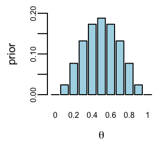

Prior

## Coin toss: Bayes rule

- Posterior: $p(\theta \mid y) = \dfrac{p(y \mid \theta)\, p(\theta)}{p(y)}$
- Marginal likelihood: $p(y) = \sum_{\theta} p(y \mid \theta)\, p(\theta)$
- Binomial likelihood, 3 tails in 10: $p(y \mid \theta) \propto \theta^3 (1 - \theta)^7$
- The posterior depends only on the counts of tails and heads: they are *sufficient* for $\theta$

```r
likelihood <- function(theta, n, Y) {
  theta^Y * (1 - theta)^(n - Y)
}
posterior <- likelihood(theta, 10, 3) * prior
posterior <- posterior / sum(posterior) # normalize
pred10 <- sum(theta * posterior)        # posterior mean
```

## Coin toss: 10 flips and 100 flips

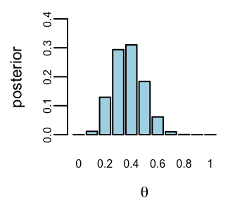

Posterior for 10 flips

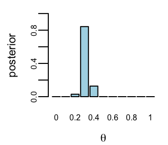

Posterior for 100 flips

```r
posterior <- likelihood(theta, 100, 30) * prior
posterior <- posterior / sum(posterior) # normalize
```

- 10 flips: posterior mean $\sum_\theta \theta\, p(\theta \mid y) = 0.375$, against $0.3$ by frequency
- 100 flips with 30 tails: the posterior concentrates around $\theta = 0.3$
- For large samples, the frequentist and Bayesian answers agree

## Beta-Binomial model

- Learning about a probability of success $\theta$, for example in A/B testing. Data $y_i$ from a Binomial with $m$ trials; $\theta$ is drawn from a Beta distribution.
  $$y_i \mid \theta \sim Binomial(m,\theta) ~\text{(likelihood)}, \quad \theta \sim Beta(\alpha,\beta) ~\text{(prior)}.$$
- Beta density, on $y\in[0,1]$ with $\alpha>0$, $\beta>0$ controlling the shape:
  $$Beta(y; \alpha, \beta) = \frac{y^{\alpha - 1}(1 - y)^{\beta - 1}}{B(\alpha, \beta)}, \qquad B\left( \alpha,\beta\right) =\int_{0}^{1}y^{\alpha-1}\left( 1-y\right)^{\beta-1}dy .$$
- $B(\alpha,\beta)$ is the beta function, a normalizing constant. Mean $\mu$ and variance $\sigma^2$:
  $$\mu = \frac{\alpha}{\alpha + \beta}, \qquad \sigma^2 = \frac{\alpha\beta}{(\alpha + \beta)^2(\alpha + \beta + 1)}$$

## Beta distributions

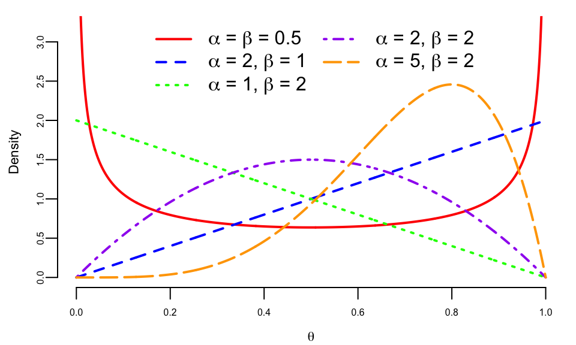

Beta distributions

## Conjugate prior and the Beta posterior

- A prior is called a *conjugate prior* for a likelihood function if the posterior distribution is of the same family as the prior distribution. Beta is conjugate to the Binomial.
- Bernoulli observations ($m=1$), $Y=\sum_{i=1}^n y_i$ the number of successes:
  $$p(\theta\mid Y) = Beta(Y+\alpha, n-Y+\beta).$$
- $Y$ is a *sufficient statistic* for $\theta$: the posterior depends on the data only through $Y$.
- General case, $n$ observations each with $m$ trials, $nm$ total Bernoulli trials:
  $$\theta\mid Y \sim Beta(Y+\alpha, nm-Y+\beta).$$
- Posterior mean and variance, with $\alpha_{n} = \alpha + Y$ and $\beta_{n} = \beta + nm - Y$:
  $$\mathbb{E}[\theta\mid Y] =\frac{\alpha_{n}}{\alpha_{n}+\beta_{n}} \;\text{ and }\; \operatorname{Var}[\theta\mid Y] =\frac{\alpha_{n}\beta_{n}}{\left( \alpha_{n}+\beta_{n}\right) ^{2}\left( \alpha_{n}+\beta_{n}+1\right) }$$

## Black swans

- After $T$ trials, all successes: the probability of success next time is $(T+1)/(T+2)$. White swans seen, never a black swan.
- Model $y_t=0$ or $1$ with $P(y_t=1\mid\theta)=\theta$. $Y=\sum_{t=1}^{T}y_t$ is the number of successes.
  $$p\left( y\mid \theta\right) =\prod_{t=1}^{T}p\left( y_{t}\mid \theta\right) =\theta^{Y}\left( 1-\theta\right)^{T-Y}.$$
- The MLE $\widehat{\theta} = T^{-1}Y$ predicts $\hat{\theta} = 1$ and is shocked by a black swan. Bayes allows for “learning”.
- Posterior is $Beta(\alpha_n,\beta_n)$ with $\alpha_{n}=\alpha+Y$, $\beta_{n}=\beta+T-Y$.
- $T=100$ white swans, $Y=100$, uniform prior $Beta(1,1)$: the posterior is $Beta(101,1)$.
  $$P(y_{T+1} = 1 \mid Y=100) = \mathbb{E}[\theta \mid Y] = \frac{\alpha_n}{\alpha_n + \beta_n} = \frac{101}{102} \approx 0.99.$$

## Black swans: probability of a black swan

- At least one black swan in the next 100 observations:
  $$P(\text{at least one black swan in next } 100 \mid Y) = \int_0^1 \left[1 - \theta^{100}\right] p(\theta \mid Y) d\theta .$$
- Monte Carlo: draw $\theta$ from the $Beta(101,1)$ posterior and average $1-\theta^{100}$ over the draws.

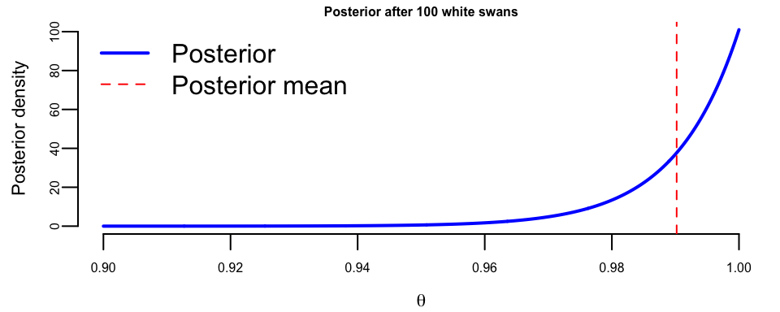

Posterior distribution after observing 100 white swans.

- Never observing a black swan, Bayes still keeps uncertainty about $\theta$ through the posterior, so rare events keep positive probability.

## Clinical trials

- $K$ drugs $a\in 1,\dots,K$ to test. The outcome with drug $a$ is binary $y(a) \in \{0,1\}$, Bernoulli with mean $f(a)$. The model is $w = f(1),\dots,f(K)$; the sample is $D = \{y_1,\dots,y_n\}$.
- Beta prior and posterior, where $n_{a,1}$ and $n_{a,0}$ count the successes and failures of drug $a$ in $D$:
  $$p(w\mid \alpha,\beta) = \prod_{a=1}^K Beta(w_a\mid \alpha,\beta), \qquad p(w\mid D) = \prod_{a=1}^K Beta(w_a\mid \alpha + n_{a,1},\beta + n_{a,0})$$
- This setup allows sequential design of experiments. The simplest version is *Thompson sampling*: after $n$ patients, draw a single sample $\tilde w$ from the posterior and maximize the resulting surrogate
  $$a_{n+1} = \arg\max_{a} \tilde w_a, ~~~ \tilde{w} \sim p(w\mid D)$$

## Clinical trial: ulcer treatments (Novick and Grizzle, 1965)

| Treatment | Excellent | Fair | Death | Total |
| --- | --- | --- | --- | --- |
| A | 76 | 17 | 7 | 100 |
| B | 89 | 10 | 1 | 100 |
| C | 86 | 13 | 1 | 100 |
| D | 88 | 9 | 3 | 100 |

- $p_i$: death rate under treatment $i$. Prior $p_i \sim \text{Beta}(1,1)$ (uniform)
- $p_A \mid \text{data} \sim \text{Beta}(1+7,\,1+93) = \text{Beta}(8, 94)$
- $p_B \mid \text{data} \sim \text{Beta}(1+1,\,1+99) = \text{Beta}(2, 100)$

## Ulcer trial: is A worse than B?

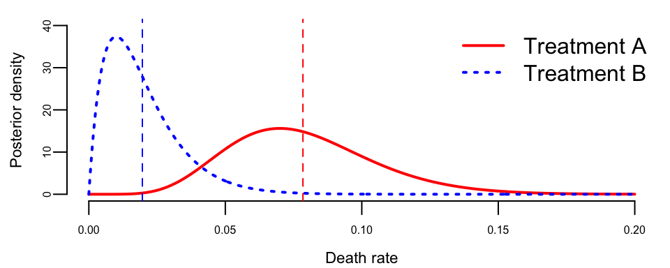

Posterior death rates. Dashed: posterior means

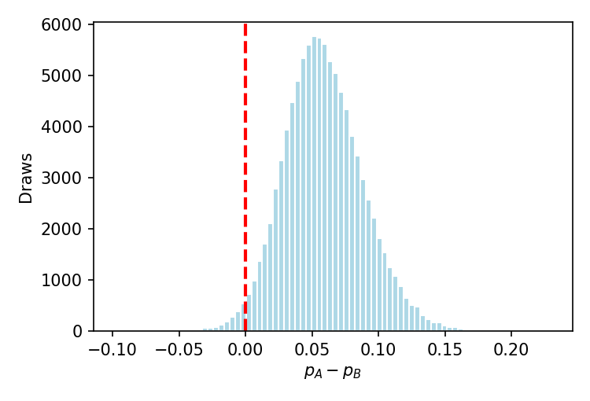

Posterior of $p_A - p_B$, 100,000 draws. Dashed: 0

- Draw $p_A \sim \text{Beta}(8,94)$ and $p_B \sim \text{Beta}(2,100)$; take the difference
- $P(p_A > p_B \mid \text{data}) \approx 0.98$: share of draws right of 0
- A near 7 to 8%, B near 1 to 2%. Mean of $p_A - p_B$: 0.059; 95% interval 0.004 to 0.122

## Ulcer trial: p-values against the posterior

- Chi-square test of homogeneity: 12.4 on 6 degrees of freedom, $p = 0.053$: fails to reject at 5%
- Fisher’s exact test on A and B only: deaths 7 of 100 (A) against 1 of 100 (B)
  - $H_0$: $p_A = p_B$. One-sided alternative: $p_A > p_B$
  - Fix the total of 8 deaths. Under $H_0$ the 8 deaths fall at random among the 200 patients, 100 per arm (hypergeometric)
  - $p = P(\text{A gets 7 or 8 of the 8 deaths} \mid H_0) = 0.032$: rejects at 5%
  - Two-sided alternative $p_A \ne p_B$: $p = 0.065$, does not reject. The one-sided direction was chosen after seeing A had more deaths
  - A and B are the worst and best of 6 possible pairs. Bonferroni cutoff: $0.05/6 = 0.0083$; $0.032$ does not pass
- Chi-square tests the whole table; the 98% answers one question: is A’s death rate higher than B’s
- Posterior probability that A is not worse than B: 0.018
- Bayesian inference is relative: which hypothesis explains the data better

| Prior | Prior mean | $P(p_A > p_B \mid \text{data})$ |
| --- | --- | --- |
| Uniform Beta(1,1) | 0.50 | 0.98 |
| Jeffreys Beta(0.5,0.5) | 0.50 | 0.99 |
| Skeptical Beta(2,20) | 0.09 | 0.97 |
| Optimistic Beta(1,10) | 0.09 | 0.98 |
| Strong Beta(5,50) | 0.09 | 0.94 |

- 100 patients per arm: the likelihood dominates the prior

## Normal with unknown mean

- $Y \sim N(\mu, \sigma^2)$, mean $\mu$ unknown, variance $\sigma^2$ known. The MLE is $\hat{\mu} = \bar{y}$, the sample mean. Normal prior $\mu \sim N(\mu_0, \sigma_0^2)$ is conjugate; the posterior is $N(\mu_n, \sigma_n^2)$:
  $$\mu_n = \frac{\sigma^2}{n\sigma_0^2 + \sigma^2}\mu_0 + \frac{n\sigma_0^2}{n\sigma_0^2 + \sigma^2}\bar{y}, \qquad \sigma_n^2 = \frac{\sigma^2\sigma_0^2}{n\sigma_0^2 + \sigma^2}$$
- The posterior mean is a weighted average of the prior mean and the sample mean, with weights proportional to the precision of the prior and the likelihood. The posterior variance is smaller than the prior variance.
- As $n \to \infty$:
  $$\frac{\sigma^2}{n\sigma_0^2 + \sigma^2} \rightarrow 0, \quad \frac{n\sigma_0^2}{n\sigma_0^2 + \sigma^2}\rightarrow 1, \quad \frac{\sigma^2\sigma_0^2}{n\sigma_0^2 + \sigma^2} \rightarrow 0 .$$
- $\bar y = \mathrm{Ave}(y_1,\ldots,y_n)$ is the sufficient statistic: $p(y \mid \mu) = N(\bar y\mid \mu,\sigma^2/n)$.

## Stylized example

- Prior $\mu \sim N(-1,1)$, observe $y=2$ with likelihood $p(y \mid \mu) = N(\mu,2^2)$. The posterior is
  $$p(\mu \mid y) \propto p(y \mid \mu) p(\mu) = N(y\mid \mu,2^2) N(\mu\mid -1,1) = N(-0.4,0.894^2).$$

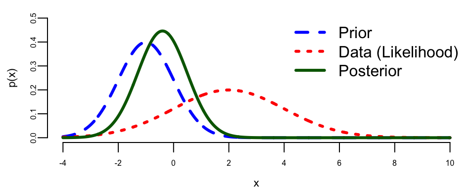

Norm-Norm Updating

- The posterior mean is between those of prior and likelihood. The posterior variance is lower than the variance of both: the effect of combining information from data and prior.

## Chicago Bears 2014 to 2015 season

- Back-to-back 50-point defeats: Patriots-Bears $51-23$, Packers-Bears $55-14$. Next game at home against the Vikings, current line $-3.5$.
- $\bar y$ is the average win/lose margin over $n =9$ games, $\mu$ its mean, $\sigma$ its standard deviation, $\tau$ the standard deviation of $\mu$. Observed $\bar{y} = -9.22$, $s = 18.34$, pre-season prior mean $\mu_0 = 0$, $\tau = 4$.
  $$\bar{y} \mid \mu \sim N \left ( \mu , \frac{\sigma^2}{n} \right ) \sim N \left ( \mu , \frac{18.34^2}{9} \right ), \qquad \mu \sim N( 0 , \tau^2 )$$
- Bayes shrinkage estimator, with shrinkage factor $0.3$:
  $$\mathbb{E}[\mu \mid \tau, \bar y] = \frac{ \tau^2 }{ \tau^2 + \frac{\sigma^2}{n} }\bar{y} .$$
- Updated estimator $\mathbb{E}[\mu \mid \bar{y}, \tau] = -2.76 > -3.5$: the line is an over-reaction. One point on the line is about $2$% on a probability scale.

## Bears: market-based $\tau$

- Calculate a market-based $\tau$ given line $=-3.5$:
  $$w = \frac{3.5}{9.22} = 0.38, \quad \tau^2 = \frac{w}{1-w}\,\frac{\sigma^2}{n} \approx 22.9.$$
- The market-based $\tau$ is $\approx 4.8$ points.
- Home advantage: about $3$ points (NFL rule of thumb, an assumption)
- $\mu$ averages home and away games; the line $-3.5$ is for this home game, so home advantage is already in it
- Model’s prediction for the home game: $-2.76 + 3 \approx +0.2$, a toss-up, against the market’s $-3.5$
- Gap about $3.7$ points: the market over-reacted to the two blowouts
- Actual result: Bears 21, Vikings 13

## Posterior predictive

- The posterior predictive distribution is the distribution of a new observation $y_{n+1}$ given the observed data $y_1,\ldots,y_n$:
  $$p(y_{n+1} \mid y_1,\ldots,y_n) = \int p(y_{n+1} \mid \mu) p(\mu \mid y_1,\ldots,y_n) d\mu = N(y_{n+1} \mid \mu_n, \sigma_n^2 + \sigma^2).$$
- Follows from the general properties of the Gaussian distribution.

## Shrinkage and baseball batting averages

- Jeter’s record against individual pitchers, 2006 season. $p_i$ is his ability against pitcher $i$, $y_i$ the hits, $T_i$ the at-bats against pitcher $i$.
  $$(y_{i} \mid p_{i})\sim Bin(T_{i},p_{i})\;\;\mathrm{with}\;\;p_{i}\sim Be(\alpha,\beta)$$
- Prior mean $\mathbb{E}[p_{i}]=\alpha/(\alpha+\beta)=\bar{p}$. Prior variance $\operatorname{Var}[p_{i}]=\bar{p}(1-\bar{p})\phi$ with $\phi=(\alpha+\beta+1)^{-1}$.
- $\phi$ measures how concentrated the beta distribution is around its mean: $\phi=0$ highly concentrated, $\phi=1$ widely dispersed.
- Hierarchical model: the abilities $p_i$ share a common distribution with parameters $\alpha$ and $\beta$ estimated from the data. Shrinkage: estimates of $p_i$ are shrunk towards $\bar{p}$.
- Estimated $\hat{\phi} = 0.002$ for Jeter. Extremes are shrunk the most, and most for the smallest sample sizes.
- Jeter had a $.316$ average over these at-bats. His Bayes estimates vary from $.311$ to $.326$.

## Hierarchy: population and individuals

```
flowchart TB
  POP["<b>Population</b><br/>Beta(α, β): mean p̄, spread φ<br/>estimated from all pitchers"]
  P1["<b>Mendoza</b><br/>ability p₁"]
  P2["<b>Martinez</b><br/>ability p₂"]
  P3["<b>Julio</b><br/>ability p₃"]
  PK["<b>...</b><br/>one p_i per pitcher"]
  Y1["<b>Data</b><br/>5 hits in 6"]
  Y2["<b>Data</b><br/>21 hits in 83"]
  Y3["<b>Data</b><br/>0 hits in 13"]
  YK["<b>Data</b><br/>y_i ~ Bin(T_i, p_i)"]
  POP --> P1 & P2 & P3 & PK
  P1 --> Y1
  P2 --> Y2
  P3 --> Y3
  PK --> YK
```

- Top level: population of Jeter’s abilities against all pitchers, $p_i \sim \text{Be}(\alpha,\beta)$
- Middle level: ability $p_i$ against pitcher $i$
- Bottom level: observed hits $y_i$ in $T_i$ at-bats
- Each $p_i$ is learned from its own data and from the population. Small $\hat\phi = 0.002$: tight population, strong pull to $\bar p$ (Mendoza $.833 \to .322$)
- Fewer at-bats, stronger pull. Both $0$ hits: Kolb (5 at-bats) $\to .316$, Julio (13 at-bats) $\to .312$

## Jeter against individual pitchers

| Pitcher | At-bats | Hits | ObsAvg | EstAvg | 95% Int |
| --- | --- | --- | --- | --- | --- |
| R. Mendoza | 6 | 5 | .833 | .322 | (.282, .394) |
| H. Nomo | 20 | 12 | .600 | .326 | (.289, .407) |
| A.J.Burnett | 5 | 3 | .600 | .320 | (.275, .381) |
| E. Milton | 28 | 14 | .500 | .324 | (.291, .397) |
| D. Cone | 8 | 4 | .500 | .320 | (.218, .381) |
| R. Lopez | 45 | 21 | .467 | .326 | (.291, .401) |
| K. Escobar | 39 | 16 | .410 | .322 | (.281, .386) |
| J. Wetteland | 5 | 2 | .400 | .318 | (.275, .375) |
| T. Wakefield | 81 | 26 | .321 | .318 | (.279, .364) |
| P. Martinez | 83 | 21 | .253 | .312 | (.254, .347) |
| K. Benson | 8 | 2 | .250 | .317 | (.264, .368) |
| T. Hudson | 24 | 6 | .250 | .315 | (.260, .362) |
| J. Smoltz | 5 | 1 | .200 | .314 | (.253, .355) |
| F. Garcia | 25 | 5 | .200 | .314 | (.253, .355) |
| B. Radke | 41 | 8 | .195 | .311 | (.247, .347) |
| D. Kolb | 5 | 0 | .000 | .316 | (.258, .363) |
| J. Julio | 13 | 0 | .000 | .312 | (.243, .350 ) |
| Total | 6530 | 2061 | .316 |  |  |

## Shrinkage picture: 18 players, 1970 (Efron and Morris, 1977)

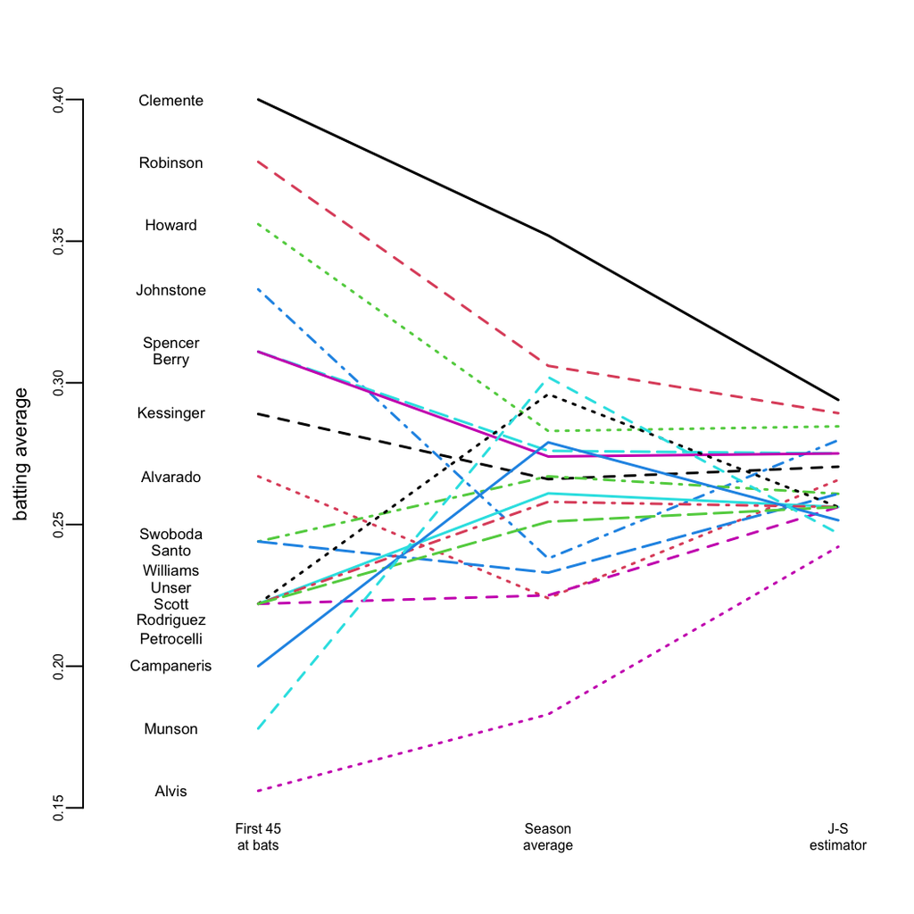

First 45 at-bats, season average and James-Stein estimate for each player.

- $y_j$: average of player $j$ after 45 at-bats. $\bar y = .265$: grand mean, $k = 18$ players
- $\sigma^2 = \bar y(1-\bar y)/45$: sampling variance of one average
- James-Stein estimate: $\bar y + c\,(y_j - \bar y)$
- $c = 1 - \dfrac{(k-3)\sigma^2}{\sum_j (y_j - \bar y)^2} = 0.21$: each estimate keeps a fifth of its distance to $\bar y$
- Clemente: $.400 \to .294$
- Error against the season average, MSE $= \frac{1}{k}\sum_j(\text{estimate}_j - \text{season}_j)^2$:
  - Observed: $0.0033$
  - James-Stein: $0.0010$
- Same idea as the Jeter model: extremes are pulled to the mean

## Lofton against Milton

- Aug 29, 2006: Kenny Lofton (career $.299$, $.308$ in 2006) faced pitcher Milton (record $1$ for $19$). He was rested and replaced by a $.273$ hitter.
- $P\left( \leq 1\;\mathrm{hit\;in}\ 19\;\mathrm{attempts} \mid p=0.3\right) =0.01$, a 1-in-100 event. This ignores the multiplicity of batter-pitcher match-ups.
- Hierarchical analysis of Lofton: $\phi=0.008$, four times larger than Jeter’s $\phi=0.002$.
- His estimates vary from $.265$ to $.340$, the lowest against Milton.
- The estimate against Milton is $.265<.273$: resting Lofton is justified by this analysis.

## Poisson-Gamma: learning about an intensity

- $N_t$ counts events up to time $t$, with $N_0=0$. The probability of an event over a short interval $\Delta t$ is $\lambda\Delta t$, where $\lambda$ is the intensity. $N_t\sim Poi(\lambda t)$:
  $$P\left[ N_{t}=k\right] =\frac{e^{-\lambda t}\left( \lambda t\right) ^{k}}{k!}\text{ for }k=0,1,\ldots$$
- Learn $\lambda$ from observations up to time $t$. The MLE is $\widehat{\lambda}=N_{t}/t$, and $N_t$ with $t$ is sufficient for $\lambda$.
- The MLE is 0 before the first event, although the model assumes events are possible (default risk in credit).
- Gamma prior with hyperparameters $a$, $A$:
  $$p\left( \lambda \mid a,A\right) =\frac{A^{a}}{\Gamma(a) }\lambda^{a-1}\exp\left( -A\lambda\right) .$$

## Poisson-Gamma posterior

- The posterior is also Gamma, with $a_{t}=N_{t}+a$ and $A_{t}=t+A$:
  $$p\left( \lambda \mid N_{t}\right) \propto \lambda^{N_{t}+a-1}\exp\left( -\lambda\left( t+A\right) \right) \sim\mathcal{G}\left( a_{t},A_{t}\right).$$
- Posterior mean in shrinkage form, a weighted average of the MLE and the prior mean, with $w_{t}=t/(t+A)$:
  $$\mathbb{E}[\lambda \mid N_{t}] =\frac{a_{t}}{A_{t}}=\frac{N_{t}+a}{t+A}=w_{t}\frac{N_{t}}{t}+\left( 1-w_{t}\right) \frac{a}{A}.$$
- In large samples $w_{t}\rightarrow1$ and $\mathbb{E}[\lambda \mid N_{t}] \approx N_{t}/t=\widehat{\lambda}$.
- Generic properties: upward revision at event times and $1/(t+A)$ decay during periods of no events.

## Four Gamma priors

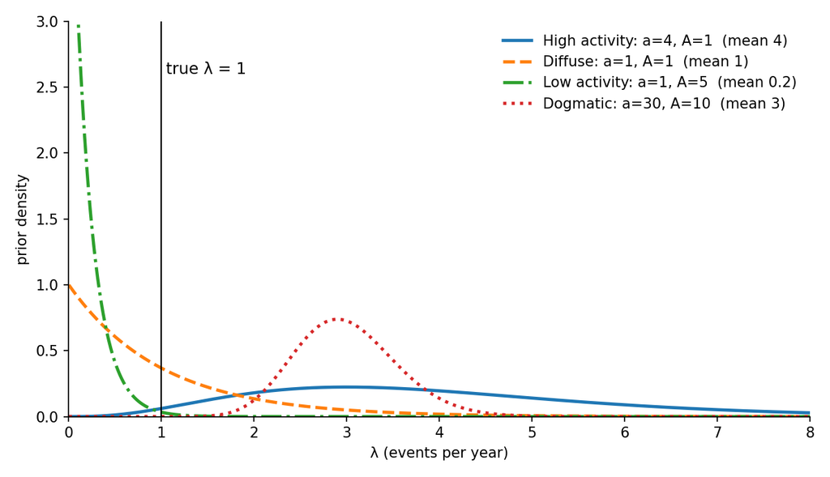

Prior densities $p(\lambda \mid a, A)$. Vertical line: true $\lambda = 1$ used in the simulation.

- Prior mean: $a/A$. Prior SD: $\sqrt{a}/A$. Weight on the data: $w_t = t/(t+A)$

| Prior | $a$ | $A$ | Mean | SD | 90% interval | Belief |
| --- | --- | --- | --- | --- | --- | --- |
| High activity | 4 | 1 | 4 | 2 | 1.37 to 7.75 | many events, uncertain |
| Diffuse | 1 | 1 | 1 | 1 | 0.05 to 3.00 | little information |
| Low activity | 1 | 5 | 0.2 | 0.2 | 0.01 to 0.60 | few events |
| Dogmatic | 30 | 10 | 3 | 0.55 | 2.16 to 3.95 | wrong and confident |

## Sensitivity of the Gamma prior

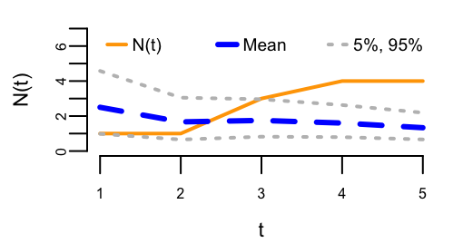

High activity: $a = 4$, $A = 1$

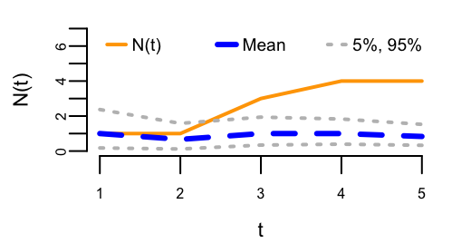

Diffuse: $a = 1$, $A = 1$

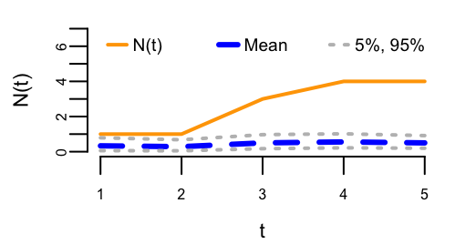

Low activity: $a = 1$, $A = 5$

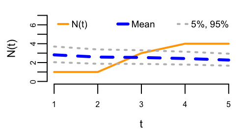

Dogmatic: $a = 30$, $A = 10$

- Time in years, simulated intensity $\lambda=1$. Solid line: cumulative count $N_t$; thick dashed: posterior mean of $\lambda$; dotted: 5% and 95% posterior quantiles.
- $A$ acts like $A$ years of prior data. Dogmatic, $A = 10$: after $t = 10$ years the data get only half the weight, $w_{10} = 10/20$

## Normal with unknown variance, and the Normal-Gamma model

- Known mean $\mu$, unknown variance. Conjugate prior: the inverse Gamma, with posterior $IG(\alpha_{\mathrm{posterior}},\beta_{\mathrm{posterior}})$ for one observation $y$:
  $$\alpha_{\mathrm{posterior}} = \alpha + \dfrac{1}{2}, ~~\beta_{\mathrm{posterior}} = \beta + \dfrac{(y-\mu)^2}{2}.$$
- The predictive distribution of $y_{new}$ is a $t$-distribution with $2\alpha_{\mathrm{posterior}}$ degrees of freedom, mean $\mu$ and variance $\beta_{\mathrm{posterior}}/(\alpha_{\mathrm{posterior}}-1)$.
- Both unknown, with precision $\tau = 1/\sigma^2$: $y_i \mid \theta, \tau \sim N(\theta, 1/\tau)$ with Normal-Gamma prior, $\nu$ scaling the precision of $\theta$:
  $$\theta\mid \mu,\tau,\nu \sim N(\mu, 1/(\tau \nu)), \quad \tau \mid \alpha, \beta \sim \text{Gamma}(\alpha, \beta).$$
- The posterior is Normal-Gamma with $\mu_n = \dfrac{\nu\mu + n\bar{y}}{\nu+n}$, $\nu_n = \nu+n$, $\alpha_n = \alpha + \dfrac{n}{2}$ and
  $$\beta_n = \beta + \dfrac{1}{2}\sum_{i=1}^n(y_i-\bar{y})^2 + \dfrac{n\nu}{2(\nu+n)}(\bar{y}-\mu)^2.$$
- The marginal of $\theta$ is a Student’s $t$ centered at $\mu_n$ with squared scale $\beta_n/(\nu_n\alpha_n)$ and $2\alpha_n$ degrees of freedom.

## Bayesian computation: when conjugacy breaks

- Most realistic models are not conjugate: the posterior exists but has no closed form. The remedy is simulation: draws $\theta^{(1)},\ldots,\theta^{(N)} \sim p(\theta\mid y)$ turn posterior summaries into Monte Carlo averages:
  $$\mathbb{E}[g(\theta)\mid y] \approx \frac{1}{N}\sum_{n=1}^N g(\theta^{(n)}).$$
- *Posterior consistency*: the posterior concentrates around the true value $\mu^\ast$ as data accumulate. For $x_i \sim N(\mu^\ast, \sigma^2)$ and prior $\mu \sim N(\mu_0, \tau_0^2)$:
  $$\mathbb{E}[\mu \mid x_1, \ldots, x_n] = \frac{\tau_0^{-2}\mu_0 + n\sigma^{-2}\bar{x}_n}{\tau_0^{-2} + n\sigma^{-2}} \to \mu^\ast \quad \text{almost surely}.$$
- The prior matters for small samples and becomes negligible for large samples.
- Monte Carlo: $\hat{\mu}_n = \frac{1}{n}\sum_{i=1}^n f(x_i) \to \mathbb{E}[f(X)]$ by the strong law of large numbers. The error decreases at rate $O_p(n^{-1/2})$.
- Posterior predictive simulation: $\theta^{(n)} \sim p(\theta\mid y)$, then $\tilde y^{(n)} \sim p(\tilde y\mid \theta^{(n)})$.

## Markov chain Monte Carlo

- Build a Markov chain with transition kernel $P(x, y)$ whose stationary distribution is the posterior $\pi$:
  $$\pi(y) = \int \pi(x) P(x, y) dx, \qquad \frac{1}{n}\sum_{i=1}^n f(x^{(i)}) \to \mathbb{E}_\pi[f(x)] \quad \text{almost surely}.$$
- Only the *ratio* of densities $\pi(y)/\pi(x)$ is needed, so intractable normalizing constants do not matter.
- *Metropolis-Hastings*: propose $y$ from a symmetric proposal $q(x, y)$ and accept with probability
  $$\alpha(x, y) = \min\left(\frac{\pi(y)}{\pi(x)}, 1\right).$$
- *Gibbs sampler*: cycle through the coordinates of $x = (x_1, \ldots, x_p)$, sampling each from its full conditional; the acceptance probability is always one:
  $$x_j^{(t+1)} \sim \pi(x_j \mid x_1^{(t+1)}, \ldots, x_{j-1}^{(t+1)}, x_{j+1}^{(t)}, \ldots, x_p^{(t)})$$

## SAT coaching in eight schools: the data

- Randomized experiments of coaching programs for the verbal SAT (scored 200 to 800) in eight high schools (Rubin, 1981)
- $y_j$: estimated effect of coaching in school $j$, in SAT points. $\sigma_j$: its standard error
- 95% interval: $y_j \pm 1.96\,\sigma_j$

| School | $y_j$ | $\sigma_j$ | 95% interval |
| --- | --- | --- | --- |
| A | 28 | 15 | -1 to 57 |
| B | 8 | 10 | -12 to 28 |
| C | -3 | 16 | -34 to 28 |
| D | 7 | 11 | -15 to 29 |
| E | -1 | 9 | -19 to 17 |
| F | 1 | 11 | -21 to 23 |
| G | 18 | 10 | -2 to 38 |
| H | 12 | 18 | -23 to 47 |

- All intervals overlap and all contain 0 (A and G barely)

## SAT coaching in eight schools: the model

- $\theta_j$: true average effect of the program in school $j$. Goal: estimate $\theta_j$ from $y_j$.
- Two programs appear to work, 28 and 18 points, but the standard errors are large. Classical test: $\sum_j (y_j-\hat\theta)^2/\sigma_j^2 = 4.7$ on 7 degrees of freedom, $p = 0.70$. Pooled estimate:
  $$\hat\theta = \frac{\sum_j y_j/\sigma_j^2}{\sum_j 1/\sigma_j^2} = 7.7, \quad \text{standard error } 4.1.$$
- Taken separately, School A gains 28 points; pooled, it gains no more than School E.
- Hierarchical model, effects exchangeable, $\sigma_j^2$ known. $\mu$ and $\tau$ are the mean and standard deviation of the effects:
  $$y_j \mid \theta_j \sim N(\theta_j, \sigma_j^2),\qquad \theta_j \mid \mu, \tau \sim N(\mu, \tau^2),\qquad p(\mu, \tau^2) \propto 1/\tau .$$
- As $\tau \to 0$: complete pooling. As $\tau \to \infty$: separate estimates.

## Eight schools: Gibbs sampler

- The joint posterior is not a familiar family, but every full conditional is:
  $$\begin{aligned}
  \theta_j \mid \mu, \tau, y &\sim N\left(v_j\left(\frac{y_j}{\sigma_j^2} + \frac{\mu}{\tau^2}\right), v_j\right),\qquad v_j = \left(\frac{1}{\sigma_j^2} + \frac{1}{\tau^2}\right)^{-1},\\
  \mu \mid \theta, \tau &\sim N(\bar\theta, \tau^2/8),\\
  \tau^2 \mid \theta, \mu &\sim \text{Inv-Gamma}\left(\frac{7}{2}, \frac{1}{2}\sum_j (\theta_j-\mu)^2\right).
  \end{aligned}$$
- The variances are unequal, so the shrinkage differs: the larger $\sigma_j$, the more weight the conditional mean of $\theta_j$ puts on $\mu$.

## Eight schools: posterior quantiles

| School | $y_j$ | $\sigma_j$ | 2.5% | 25% | 50% | 75% | 97.5% |
| --- | --- | --- | --- | --- | --- | --- | --- |
| A | 28 | 15 | -2.2 | 6.0 | 10.2 | 15.5 | 31.5 |
| B | 8 | 10 | -4.6 | 4.0 | 7.9 | 11.7 | 20.6 |
| C | -3 | 16 | -11.6 | 2.0 | 6.6 | 10.8 | 20.5 |
| D | 7 | 11 | -5.7 | 3.7 | 7.6 | 11.6 | 20.9 |
| E | -1 | 9 | -9.0 | 1.4 | 5.6 | 9.4 | 16.3 |
| F | 1 | 11 | -8.6 | 2.3 | 6.5 | 10.4 | 18.5 |
| G | 18 | 10 | -1.2 | 6.1 | 10.0 | 14.5 | 26.0 |
| H | 12 | 18 | -7.1 | 3.9 | 8.2 | 12.7 | 25.6 |
| $\mu$ |  |  | -2.2 | 4.6 | 7.9 | 11.1 | 18.2 |
| $\tau$ |  |  | 0.2 | 2.4 | 5.2 | 9.1 | 20.7 |

- School A falls from 28 to a median of about 10, the same as School G, which reported 18. Every 95% interval contains zero.
- Posterior of $\tau$: median near 5, interval from near 0 to about 21. The data do not settle how much to pool.
- Draws of $\tau$ have autocorrelation 0.78 at lag 1 and 0.04 at lag 50.

## MAP estimation and regularization

- Data $(x_i, y_i)$, $i = 1,\dots,N$. MAP learns $f$ by minimizing loss plus penalty:
  $$\underset{f}{\mathrm{minimize}} \quad \sum_{i=1}^N \mathcal{L}(y_i,f(x_i)) + \lambda \phi(f)$$
- $\mathcal{L}$: loss, the negative log-likelihood. Normal $y_i \mid x_i \sim N(f(x_i),\sigma^2)$ gives squared loss $(y-f(x))^2$
- $\phi(f)$: penalty on complex $f$. $\lambda$: trade-off between fit and simplicity
- Negative log posterior: $-\log p(f \mid y, x) = -\sum_i \log L(y_i,f(x_i)) - \log p(f) + \log p(y \mid x)$
- So the penalty is a prior:
  $$\lambda \phi(f) = -\log p(f)$$
- MAP: the posterior mode, a “poor man’s Bayesian”

## Ridge: a Normal prior

- Model $f(x) = x^\top\beta$. Prior $\beta \sim N(0, \sigma_\beta^2 I)$, so $-\log p(\beta) = \frac{1}{2\sigma_\beta^2}\|\beta\|_2^2 + \text{const}$
- $\|\beta\|_2^2 = \sum_{j=1}^p \beta_j^2$. $\sigma^2$: noise variance. $\sigma_\beta^2$: prior variance
  $$\underset{\beta}{\mathrm{minimize}}\quad \|y- X\beta\|_2^2 + \lambda \|\beta\|_2^2, \qquad \lambda = \sigma^2/\sigma_\beta^2$$
  $$\hat{\beta}_{\text{ridge}} = ( X^\top X + \lambda I )^{-1} X^\top y, \qquad \hat{\beta}_{\text{OLS}} = ( X^\top X )^{-1} X^\top y \;\; (\lambda = 0)$$
- $\lambda = 0$: maximum likelihood. Large $\lambda$: the prior mean, 0
- $\lambda I$ shifts the eigenvalues of $X^\top X$ away from zero: stable when $X$ is ill-conditioned (Hoerl and Kennard, 1970)
- Same as: minimize $\|y - X\beta\|_2^2$ subject to $\|\beta\|_2^2 \le t$ (Tikhonov, 1943). Choose $\lambda$ by cross-validation

## Ridge: shrinkage example

[figure not shown]

Prediction error against $\lambda$

[figure not shown]

Bias-variance decomposition

- Simulated: $n = 50$, $p = 30$, $\sigma^2 = 1$; 10 large coefficients between 0.5 and 1
- OLS: squared bias 0.006, variance 0.627, prediction error $1 + 0.006 + 0.627 = 1.633$
- Ridge at $\lambda \approx 6$: squared bias 0.077, variance 0.402, error $1 + 0.077 + 0.402 = 1.48$, about 9% better
- More bias, much less variance: the prior says coefficients are small

## Lasso: a Laplace prior

- Prior $\beta_j \sim \text{Laplace}(0, b)$ independently; $b > 0$: the scale
  $$p(\beta_j \mid b) = \frac{1}{2b}\exp\left(-\frac{|\beta_j|}{b}\right)$$
  $$-\log p(\beta) = \frac{1}{b} \|\beta\|_1 + \text{const}, \qquad \|\beta\|_1 = \sum_{j=1}^p |\beta_j|$$

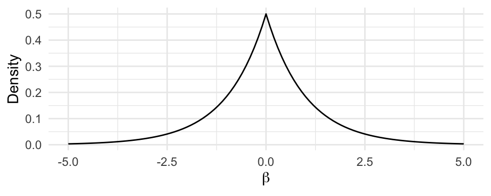

Laplace density, $b = 1$

$$\underset{\beta}{\mathrm{minimize}}\quad \|y- X\beta\|_2^2 + \lambda \|\beta\|_1, \qquad \lambda = 2\sigma^2/b$$

- No closed form; coordinate descent with soft thresholding: $\text{soft}(z, \gamma) = \text{sign}(z)(|z| - \gamma)_+$
- Sparsity: many $\hat\beta_j$ exactly 0. The constraint $\|\beta\|_1 \le t$ is a diamond with corners on the axes
- Large prior scale $b$ means small penalty $\lambda$

## Lasso: sparsity and variable selection

```r
# n = 100, p = 20 correlated predictors, sigma = 1
beta_true <- c(3, -2, 1.5, 0, 0, 2, 0, 0, 0, -1, rep(0, 10))
y <- X %*% beta_true + sigma * rnorm(n)
lasso_fit <- glmnet(X, y, alpha = 1)            # path over lambda
cv_lasso  <- cv.glmnet(X, y, alpha = 1, nfolds = 10)
```

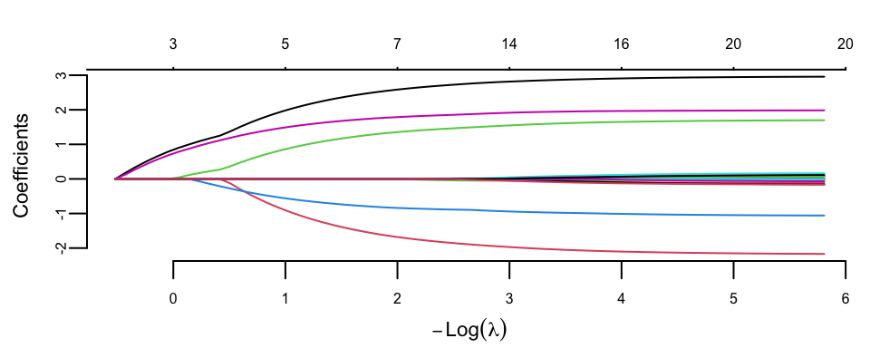

Coefficient paths

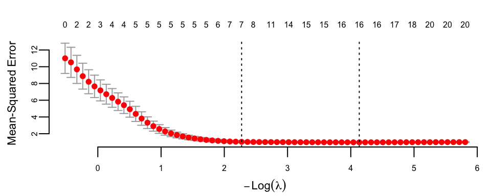

Cross-validation

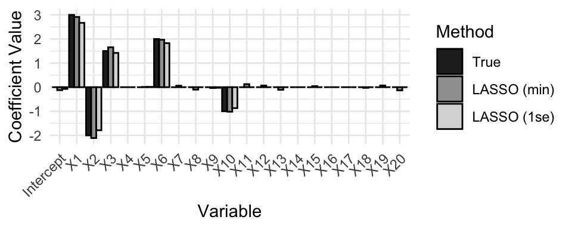

Estimates against truth

- $\lambda_{\min} = 0.016$ (minimum CV error), $\lambda_{1se} = 0.1$ (largest within one standard error)
- In-sample MSE: 0.68 at $\lambda_{\min}$, 0.85 at $\lambda_{1se}$
- All true signals kept; some noise variables also kept, fewer at $\lambda_{1se}$

## Multi-armed bandit experiments

- Classical A/B tests fix the sample size and wait. A multi-armed bandit adaptively allocates traffic based on accumulating evidence (Google Analytics Content Experiments).
- Two features: the goal is to find the best or most profitable action (*arm*), and the randomization distribution is updated as the experiment progresses.
- Gambler facing slot machines with unknown payoff rates: *exploiting* arms that performed well versus *exploring* new or seemingly inferior arms.
- Gittins: for the discounted problem, optimal policies have an index form. The *Gittins index* of an arm depends only on its own state (current posterior) and the discount factor; always play the arm with the highest index.
- It can be computationally intensive. In practice, simpler heuristics like Thompson sampling are widely used and often near-optimal.

## The Bayesian approach to bandits

- $K$ arms, each with unknown success probability $\theta_k$, $k = 1, \ldots, K$. $x_k$ is the number of successes and $n_k$ the number of trials for arm $k$. With a Beta prior $\theta_k \sim \text{Beta}(\alpha, \beta)$:
  $$\theta_k \mid x_k, n_k \sim \text{Beta}(\alpha + x_k, \beta + n_k - x_k).$$
- The probability that arm $k$ is optimal, computed by Monte Carlo (sample the posteriors and count how often arm $k$ produces the largest sample):
  $$P(\theta_k > \theta_j \text{ for all } j \neq k \mid \text{data}).$$
- Posterior probabilities of optimality serve directly as allocation weights: an arm that does well receives more traffic, an underperforming arm less.

## Thompson sampling

- One of the oldest heuristics for the bandit problem (1933). For binary outcomes with Beta priors:
1. Initialize $\alpha_k = \beta_k = 1$ for each arm (uniform prior).
2. At each decision point, sample $\tilde{\theta}_k$ from the current posterior $\text{Beta}(\alpha_k, \beta_k)$ for each arm.
3. Select the arm with the highest sampled value: $a_t = \arg\max_k \tilde{\theta}_k$.
4. Observe the outcome $Y_t \in \{0, 1\}$ and update: $\alpha_{a_t} \leftarrow \alpha_{a_t} + Y_t$, $\beta_{a_t} \leftarrow \beta_{a_t} + (1 - Y_t)$.
- Arms with high posterior means are selected frequently (exploitation); arms with high posterior variance also have a chance of producing high samples (exploration).
- As data accumulates, posteriors concentrate around true values and the algorithm increasingly exploits the best arm.

## Power and sample size

- Test $H_0$: no difference between the two pages. Two possible errors:
  - Type I, size $\alpha$: declare a difference that is not there. Usual $\alpha = 0.05$
  - Type II, $\beta$: miss a difference that is there
- Power $= 1 - \beta$: probability of detecting a difference that is really there
- Power calculation: the sample size that gives the chosen power for a chosen difference
- Two conversion rates $p_1, p_2$, average $\bar p = (p_1+p_2)/2$, $n$ visitors per arm:
  $$n = \frac{\left(z_{1-\alpha/2}\sqrt{2\bar p(1-\bar p)} + z_{1-\beta}\sqrt{p_1(1-p_1)+p_2(1-p_2)}\right)^2}{(p_2-p_1)^2}$$
- $z_q$: normal quantile. $z_{0.975} = 1.96$; $z_{0.95} = 1.645$ (95% power); $z_{0.80} = 0.842$ (80% power)
- Scott’s example: $p_1 = 0.04$, $p_2 = 0.05$, $\bar p = 0.045$
  $$n = \frac{(1.96 \times 0.293 + 1.645 \times 0.293)^2}{0.01^2} \approx 11{,}165 \text{ per arm}, \quad 2n = 22{,}330$$
- At 100 visits per day: $22{,}330/100 \approx 223$ days. At 80% power: about 6,700 per arm
- Small differences are expensive: $n$ grows like $1/(p_2-p_1)^2$

## Bandits against classical A/B testing

- Bandits are just as statistically valid but produce answers far more quickly: traffic moves toward winners gradually, and samples that would go to inferior variations go to potential winners.
- Example from Scott: a website has a 4% conversion rate, the new variation converts at 5%.
- Power calculation (previous slide): 22,330 observations, 223 days at 100 visits per day.
- Scott’s single run ended after 66 days, saving 157 days. Over 500 repetitions the bandit identified the correct arm in 482 (96.4%) and saved an average of 175 days.
- With more arms the classical approach needs Bonferroni-type corrections; the bandit handles multiple arms through the posterior probabilities.

## Reproducing Scott’s bandit experiment

- Original page converts at 4%, variation at 5%, 100 visits per day. The classical power calculation requires 223 days.
- Traffic is split by *serving weights* equal to the current posterior probability that each arm is best, held fixed for the day and refreshed overnight. Day 1 splits traffic evenly.
- The stopping rule is tested on the posterior that already includes the day’s data.
- An experiment cannot end before two weeks; without that floor about a fifth of runs declare a winner within five days on a few hundred visits.

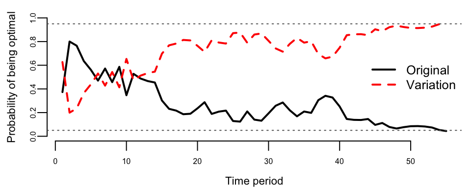

Probability that each arm is optimal at the end of each day in a single run of the bandit experiment. The dotted lines mark the 5% and 95% thresholds.

- The two curves sum to 1 and fluctuate until one crosses the 95% threshold. One run is one draw from a wide distribution, not a target.

## Bandit simulation: 500 runs

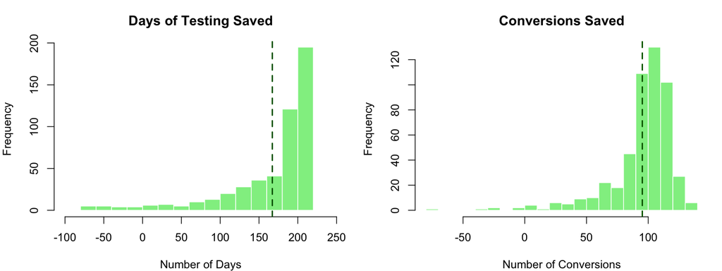

Distribution of days saved and conversions saved.

| Metric | Value | Scott’s value |
| --- | --- | --- |
| Correct arm identified | 479 / 500 (95.8%) | 482 / 500 (96.4%) |
| Median days to finish | 31 | not reported |
| Average days to finish | 55.8 | 48 |
| Average days saved | 167.2 | 175 |
| Average conversions saved | 95.2 | 97.5 |

## Stopping rules, value remaining, and regret

- Scott describes two complementary stopping criteria. First: the probability that a variation beats the original; at 95% confidence a winner can be declared.
- Second: the *value remaining in the experiment*, the expected improvement from switching away from the current champion. End when there is at least a 95% probability that the value remaining is less than 1% of the champion’s conversion rate.
- *Regret*: the cumulative cost of not always selecting the optimal arm.
- Response-adaptive randomization can reduce the number of patients receiving inferior treatments in clinical trials.

## Multi-armed bandits: formal setup

- *Multi-armed bandit* (MAB): balance *exploration* (trying new things) and *exploitation* (sticking with what works), minimizing *regret* (the difference between our choice and the optimal one). Outcomes must be available immediately or with a small delay.
- $K$ alternatives (arms); arm $a$ has reward distribution $f_a(y\mid \theta)$ and value $v_a(\theta)$, its expected reward. $y$ is the reward and $\theta$ the set of unknown parameters to be learned.
- Online ads: $\theta = (\theta_1,\ldots,\theta_K)$ are click probabilities of $K$ independent binomial models, $v_a(\theta) = \theta_a$.
- Website design: dummy variables $x_c$ for color (red or blue) and $x_s$ for size (27 or 40); each of the four combinations is an arm and $v_a(\theta) = P(\text{click} \mid \theta, x_c, x_s)$:
  $$\mathrm{logit} P(\text{click} \mid \theta) = \theta_0 + \theta_c x_c + \theta_s x_s + \theta_{cs}x_cx_s .$$
- Acting greedily, $\hat a = \arg\max_a v_a(\hat \theta)$, may miss better alternatives. Thompson sampling samples from each arm’s posterior and picks the highest sample. For Bernoulli rewards its regret is of order $\log T$ over $T$ steps.

## When to end experiments

- Replace the sampling step by the probability that arm $a$ is the best, then pick the arm from the discrete distribution $w_{1t},\ldots,w_{Kt}$. Here $y^t = (y_1,\ldots,y_t)$ is the history up to time $t$:
  $$w_{at} = P(a \text{ is optimal } \mid y^t) = \int P(a \text{ is optimal } \mid \theta) P(\theta \mid y^t) d\theta .$$
- Monte Carlo with $\theta^{(1)},\ldots,\theta^{(G)}\sim p(\theta \mid y^t)$ and the indicator $I(\cdot)$: the proportion of draws in which the arm was best,
  $$w_{at}\approx \dfrac{1}{G}\sum_{g=1}^G I(a = \arg\max_i v_i(\theta^{(g)})).$$
- Regret is unobservable, but its posterior can be simulated. The champion is the arm that is optimal most often:
  $$r^{(g)} = \max_a v_a(\theta^{(g)}) - v_{a^*_t}(\theta^{(g)}), \qquad a^*_t = \arg\max_a w_{at}.$$
- $v_a(\theta^{(g)})$: value (expected reward) of arm $a$ if the true parameters were draw $g$. Conversion rates: $v_a(\theta^{(g)}) = \theta_a^{(g)}$. Example: arm 3 converts with probability $0.58$ in draw 1, so $v_3(\theta^{(1)}) = 0.58$ conversions per session
- $\max_a v_a(\theta^{(g)})$: value of the best arm in draw $g$. $v_{a^*_t}(\theta^{(g)})$: value of the champion in draw $g$
- In percent scale: $r^{(g)} \leftarrow r^{(g)}/v_{a^*_t}(\theta^{(g)})$. Regret is positive exactly on the draws in which some arm beats the champion.

## Regret example: six posterior draws

- Three arms with 20, 30 and 40 sessions and 12, 20 and 30 conversions. Uniform prior $\theta_i \sim \text{Beta}(1,1)$.

Six posterior draws of the conversion rates of the three arms:

|  | $\theta_1$ | $\theta_2$ | $\theta_3$ |
| --- | --- | --- | --- |
| 1 | 0.60 | 0.63 | 0.58 |
| 2 | 0.62 | 0.62 | 0.74 |
| 3 | 0.69 | 0.53 | 0.67 |
| 4 | 0.49 | 0.59 | 0.73 |
| 5 | 0.61 | 0.51 | 0.69 |
| 6 | 0.47 | 0.64 | 0.69 |

Posterior probability that each arm is the best, from six draws:

| 1 | 2 | 3 |
| --- | --- | --- |
| 0.17 | 0.17 | 0.67 |

Regret of each of the six draws:

| 1 | 2 | 3 | 4 | 5 | 6 |
| --- | --- | --- | --- | --- | --- |
| 0.09 | 0 | 0.03 | 0 | 0 | 0 |

- Arm 3 is the champion. Row 1: $(0.63-0.58)/0.58 = 0.09$.

## Regret example: 10000 draws

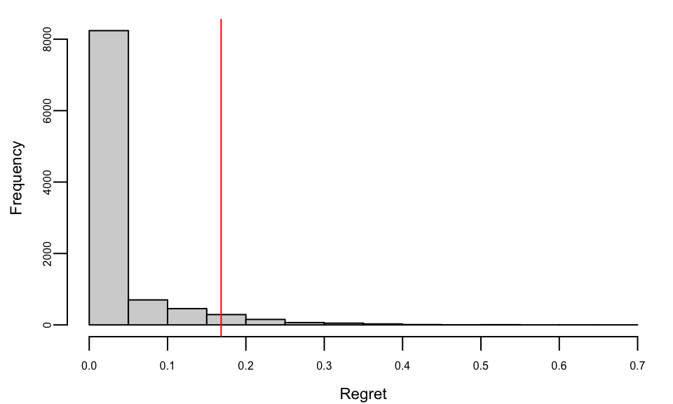

The histogram of the value remaining in an experiment (regret). The vertical line is the 95th percentile, or the potential value remaining.

Posterior probability that each arm is the best, from 10000 draws:

| 1 | 2 | 3 |
| --- | --- | --- |
| 0.08 | 0.2 | 0.72 |

- Arm 3 has a 72% probability of being best; the value of switching is zero in 72% of cases.
- The 95th percentile is the potential value remaining, about 17%: one of the other arms might beat arm 3 by as much as 17%.
- Google Analytics ends the experiment when there is at least a 95% probability that the value remaining is less than 1% of the champion’s conversion rate. Here 17% is well above 1%, so the experiment keeps running.

## Contextual bandits

- The binomial model assumes independent observations with fixed reward probabilities. This can mislead with diverse users or fluctuating activity, for example Asia, Europe and the Americas active at different times of day, or weekday browsing against weekend purchases.
- Arm A is better on weekdays, arm B on weekends. High traffic can declare A the winner before any weekend is seen; bandits are more vulnerable because their experiments are shorter.
- Known sub-populations or a proxy: use a logistic regression with context $x$. Each arm $a$ has its own intercept $\beta_{0a}$ (one set to zero as reference) and coefficients $\beta_a$ on the context:
  $$\mathrm{logit} P(\text{click}_a \mid \theta, x) = \beta_{0a} + \beta_a^\top x, \qquad v_a(\theta, x) = \mathrm{logit}^{-1}(\beta_{0a} + \beta_a^\top x).$$
- With one $\beta$ shared by all arms, the ranking of the arms could never change with the context.
- Unknown contexts: assume they are generated randomly, with a hierarchical beta-binomial model, $\theta=\{\alpha_a,\delta_a\}$ and $v_a(\theta) = \alpha_a/(\alpha_a + \delta_a)$:
  $$\theta_{at} \sim \text{Beta}(\alpha_a,\delta_a), \qquad \text{click}_a \mid \theta_{at} \sim \text{Bernoulli}(\theta_{at}).$$

## Summary of MAB experimentation

- Design: define the arms (layouts, pricing, campaigns); choose a bandit algorithm: Epsilon-greedy, Thompson Sampling, Upper Confidence Bound (UCB); set the parameters (a higher exploration rate encourages trying new arms earlier).
- Analysis: define and track the reward metric per arm (clicks, conversions, profit); monitor cumulative reward and arm selection probabilities.
- Compare arms with confidence intervals or Bayesian methods; adapt by changing parameters, stopping arms with poor performance, or introducing new arms.
- Set a clear stopping criterion: a predetermined budget, time limit, or desired level of confidence.